# Practical Data Science: Analyzing Stock Market Data with R

*Insight from Common Indicators*

In this lecture we’ll look at: * Quick look at the ADX * Quick look at volume-based indicators * Look at more trading entries

Let’s get some data:

```r
library(quantmod)
getSymbols(c('QQQ', 'SPY'), src='google')

# remove any NAs
QQQ <- QQQ[!(rowSums(is.na(QQQ))),]
SPY <- SPY[!(rowSums(is.na(SPY))),]

library(TTR)
```

There are some great indicators in the **TTR/Quantmod** package. To see them, load the libraries and type:

```
    ?add
```

and hit the TAB key. The suggestion box should pop-up filled with available indicators.

**ADX**

The **ADX** is [Welles Wilder’s Directional Movement Indicator](https://en.wikipedia.org/wiki/Average_directional_movement_index). It is used by lots of people to determine if the market is trending or range bound.

Let’s add it to the charts we were looking at earlier:

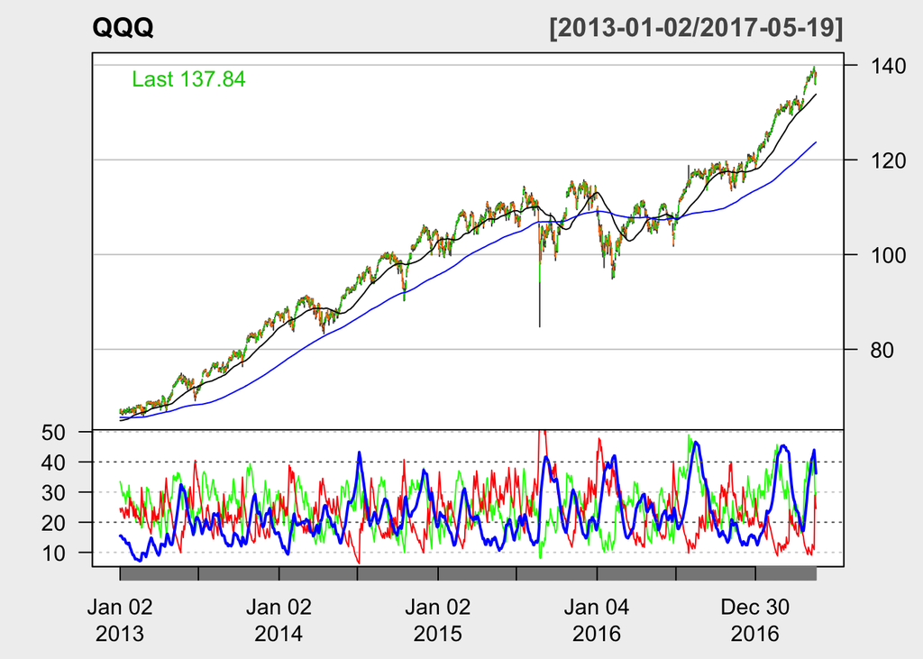

```r
chartSeries(QQQ, theme="white", TA="addSMA(50, col='black');addSMA(200, col='blue');addADX(n = 14, maType='EMA', wilder=TRUE)", subset='2013::')
```

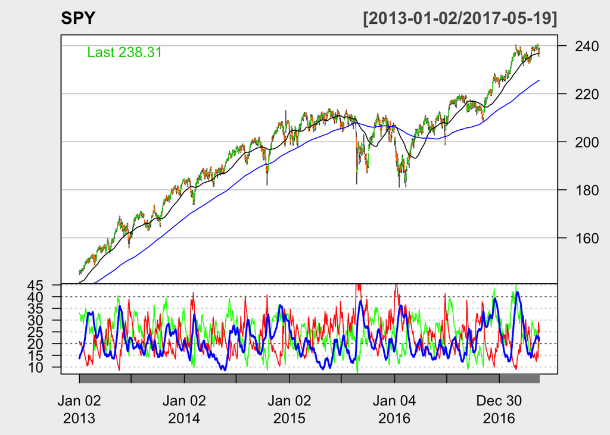

```r
chartSeries(SPY, theme="white", TA="addSMA(50, col='black');addSMA(200, col='blue');addADX(n = 14, maType='EMA', wilder=TRUE)", subset='2013::')
```

In a nutshell, Welles recommends using the ADX with a 14-day period. When the main blue line is above 20, it is considered a strong, trending market, when it is below, it is considered a weak one.

**Volume**

As this is an introductory course, we’re mostly using the closing price but it is important to note that there are a lot of other market variables available. You can design systems with the open price, the high or low, the difference between the open and close, etc. And there is also the **volume**.

This an important indicator. A falling stack on rising volume or a rising stock on falling volume may mean the move is about to reverse. Whatever the reason for abnormal volume, it should be a warning to keep a vigilant eye on the stock.

There are plenty of indicators that include the volume price such as the [Volume-weighted average price (VWAP)](https://en.wikipedia.org/wiki/Volume-weighted_average_price). The **VWAP** is a guide more than a trading indicator as to where the market is trading compared to the volume adjusted price. It divides dollars traded by volume (see above link for more details).

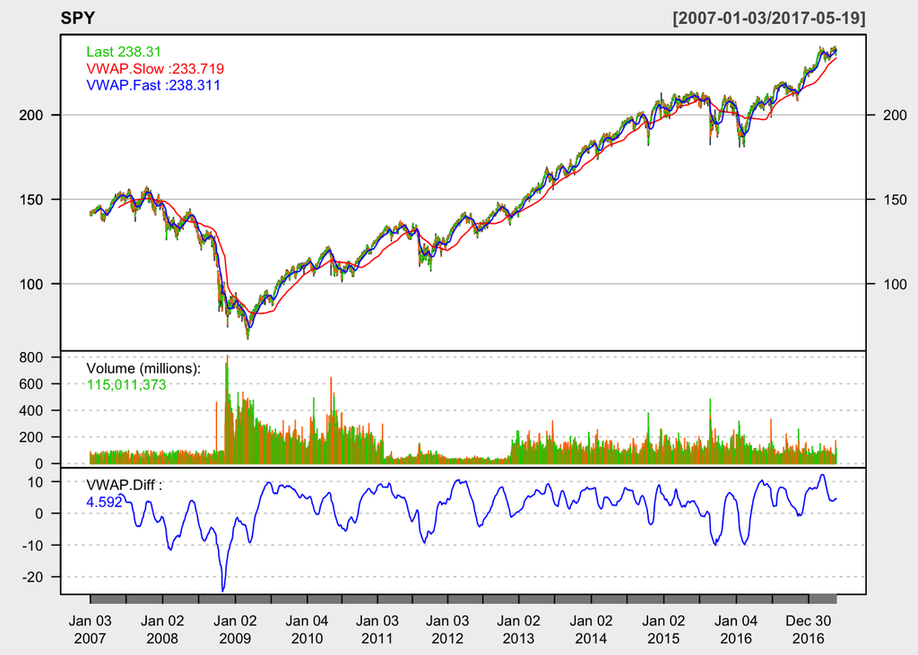

```r
VWAP.Slow <- VWAP(price=SPY$SPY.Close, volume=SPY$SPY.Volume, n=100)
VWAP.Fast <- VWAP(price=SPY$SPY.Close, volume=SPY$SPY.Volume, n=20)
VWAP.Diff <- VWAP.Fast- VWAP.Slow

chartSeries(SPY, theme="white", TA="addVo();addTA(VWAP.Slow, on=1, col='red');addTA(VWAP.Fast, on=1, col='blue');addTA(VWAP.Diff, col='blue')")
```

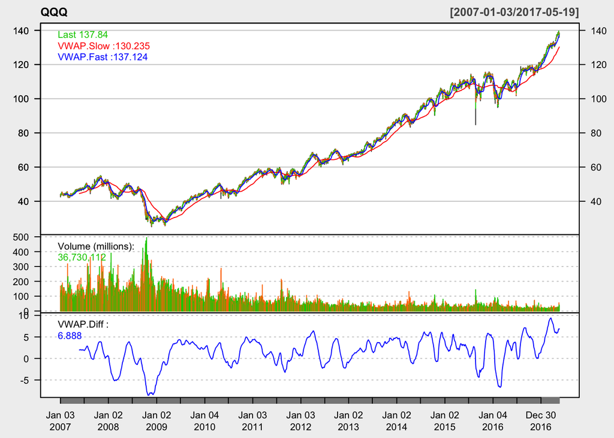

```r
VWAP.Slow <- VWAP(price=QQQ$QQQ.Close, volume=QQQ$QQQ.Volume, n=100)
VWAP.Fast <- VWAP(price=QQQ$QQQ.Close, volume=QQQ$QQQ.Volume, n=20)
VWAP.Diff <- VWAP.Fast- VWAP.Slow

chartSeries(QQQ, theme="white", TA="addVo();addTA(VWAP.Slow, on=1, col='red');addTA(VWAP.Fast, on=1, col='blue');addTA(VWAP.Diff, col='blue')")
```

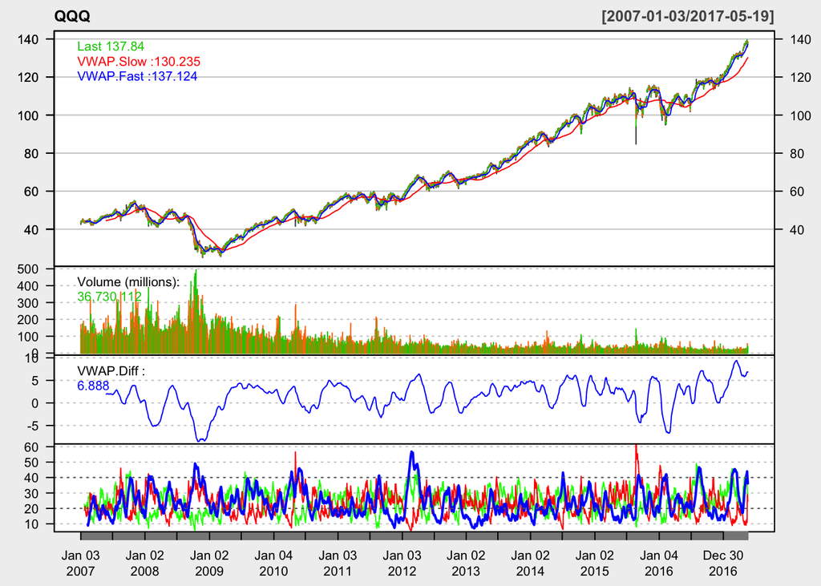

```r
chartSeries(QQQ, theme="white", TA="addVo();addTA(VWAP.Slow, on=1, col='red');addTA(VWAP.Fast, on=1, col='blue');addTA(VWAP.Diff, col='blue');
            addADX(n = 14, maType='EMA', wilder=TRUE)")
```

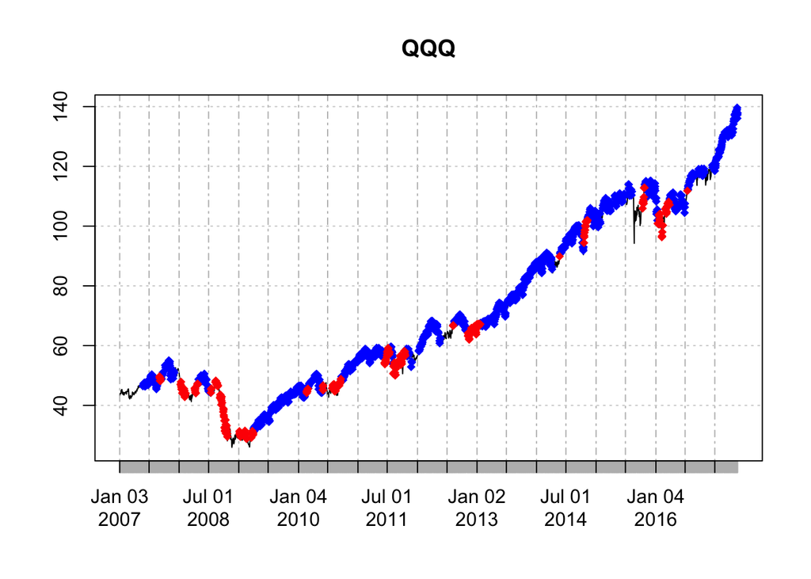

```r
ADX.20 <- ADX(QQQ,n=14)

# look for long entries
Long_Trades <- ifelse(
        ADX.20$ADX > 20 &
        VWAP.Diff> 0, QQQ$QQQ.Close, NA)

# look for long entries
Short_Trades <- ifelse(
        ADX.20$ADX > 20 &
        VWAP.Diff < 0, QQQ$QQQ.Close, NA)

plot(QQQ)
points(Long_Trades, col='blue', cex=1, pch=18)
points(Short_Trades, col='red', cex=1, pch=18)
```

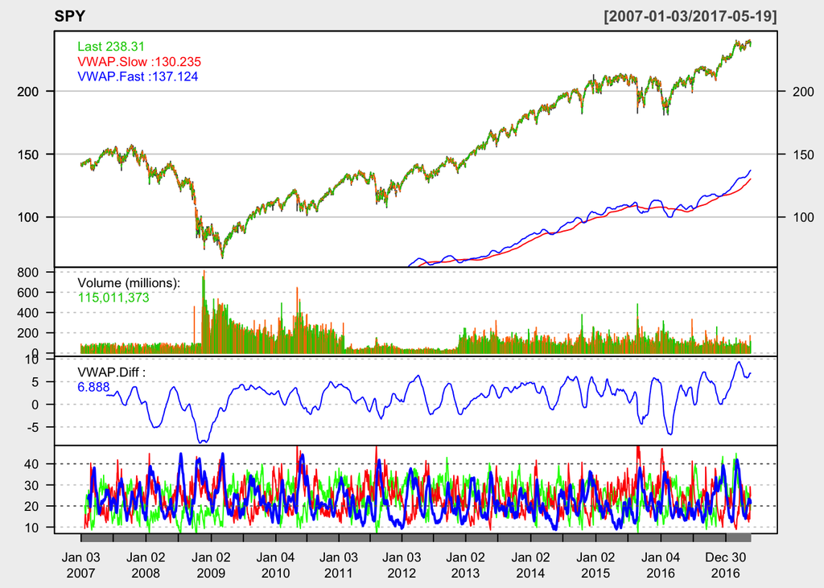

```r
chartSeries(SPY, theme="white", TA="addVo();addTA(VWAP.Slow, on=1, col='red');addTA(VWAP.Fast, on=1, col='blue');addTA(VWAP.Diff, col='blue');
            addADX(n = 14, maType='EMA', wilder=TRUE)")
```

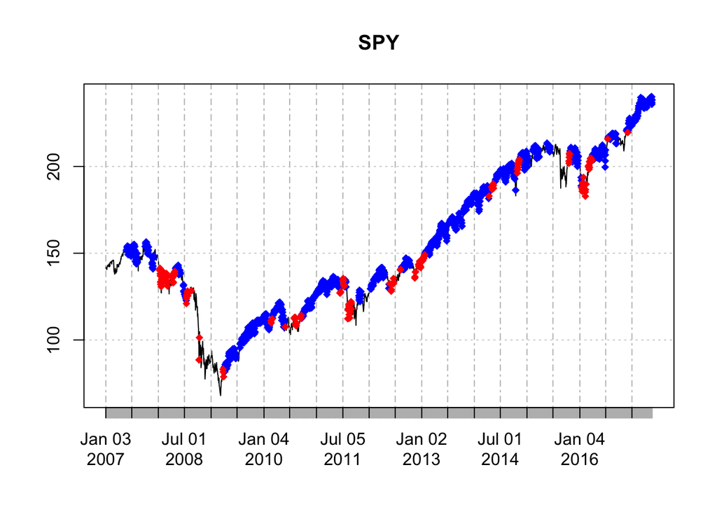

```r
ADX.20 <- ADX(SPY,n=14)

# look for long entries
Long_Trades <- ifelse(
        ADX.20$ADX > 20 &
        VWAP.Diff> 0, SPY$SPY.Close, NA)

# look for long entries
Short_Trades <- ifelse(
        ADX.20$ADX > 20 &
        VWAP.Diff < 0, SPY$SPY.Close, NA)

plot(SPY)
points(Long_Trades, col='blue', cex=1, pch=18)
points(Short_Trades, col='red', cex=1, pch=18)
```